# mlp_iris

```python
import numpy as np
import pandas as pd
import matplotlib.pyplot as plt
import seaborn as sns

from sklearn.datasets import load_iris
from sklearn.model_selection import train_test_split, cross_val_score, cross_val_predict
from sklearn.neural_network import MLPClassifier
from sklearn.metrics import accuracy_score, confusion_matrix, classification_report
from sklearn.preprocessing import StandardScaler
from sklearn.pipeline import make_pipeline

import warnings
from sklearn.exceptions import ConvergenceWarning

# Setup visualization styles and ignore warnings
warnings.filterwarnings("ignore", category=ConvergenceWarning)
sns.set_theme(style="whitegrid")
```

## 1. Data Loading & Exploratory Data Analysis (EDA)

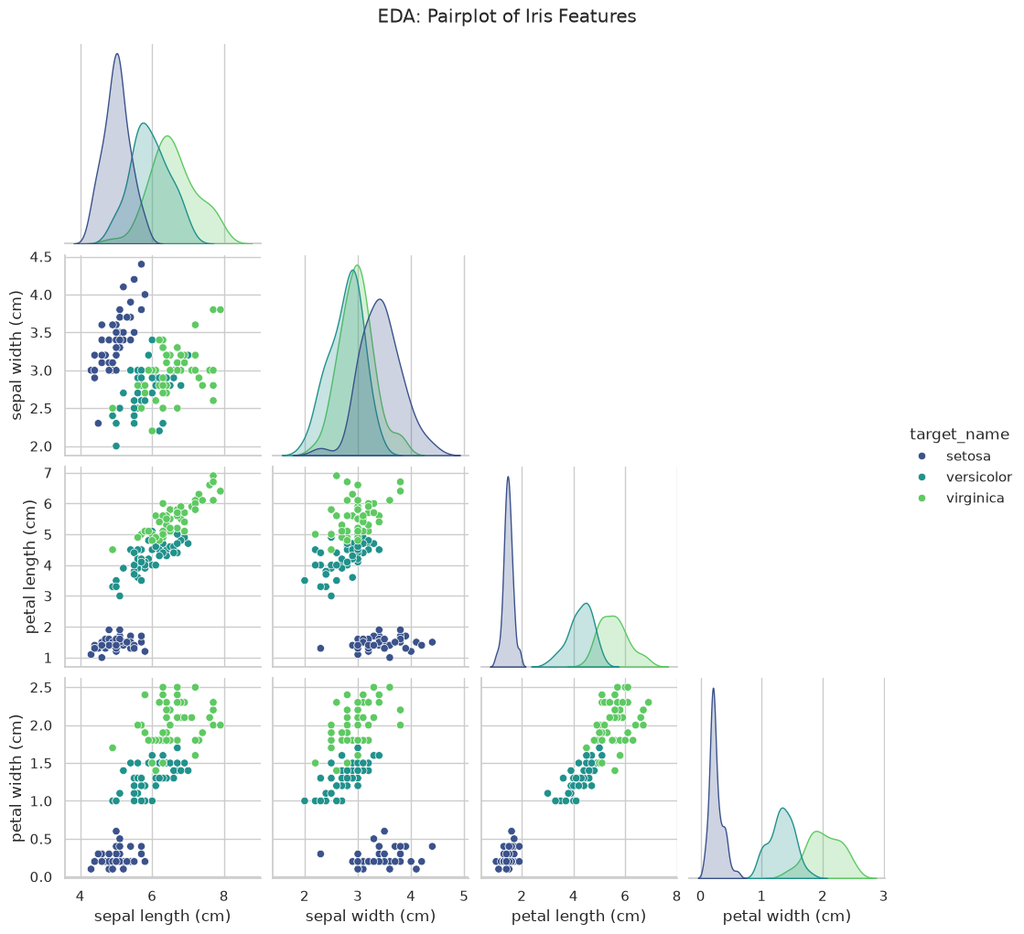

```python
# Load dataset
iris = load_iris()
df = pd.DataFrame(iris.data, columns=iris.feature_names)
df['target'] = iris.target
df['target_name'] = df['target'].map({0: 'setosa', 1: 'versicolor', 2: 'virginica'})

# Pairplot to visualize distributions
plt.figure(figsize=(10, 8))
sns.pairplot(df, hue='target_name', vars=iris.feature_names, palette='viridis', corner=True)
plt.suptitle('EDA: Pairplot of Iris Features', y=1.02)
plt.show()
```

**Observation (EDA):** `setosa` is linearly separable from the others. `versicolor` and `virginica` share a boundary and have slight overlap, which is where we expect our model to potentially make errors.

## 2. Data Cleaning & Processing Steps

```python
print("--- Data Cleaning Check ---")
print("Checking for missing values (NaNs):")
print(df.isnull().sum())
print("\nChecking data types:")
print(df.dtypes)
```

```
--- Data Cleaning Check ---
Checking for missing values (NaNs):
sepal length (cm)    0
sepal width (cm)     0
petal length (cm)    0
petal width (cm)     0
target               0
target_name          0
dtype: int64

Checking data types:
sepal length (cm)    float64
sepal width (cm)     float64
petal length (cm)    float64
petal width (cm)     float64
target                 int64
target_name              str
dtype: object
```

**Observation (Data Cleaning):** The dataset is perfectly clean. There are 0 missing values, and all feature columns are `float64`. No imputation or categorical encoding (like One-Hot Encoding) is required.

## 3. Train / Test Split (Crucial for preventing Data Leakage)

```python
X = iris.data
y = iris.target

# Split: 80% for Training/Cross-Validation, 20% for Final Holdout Testing
X_train, X_test, y_train, y_test = train_test_split(X, y, test_size=0.2, random_state=42, stratify=y)

print(f"Training set size: {X_train.shape[0]} samples")
print(f"Testing set size: {X_test.shape[0]} samples")
```

```
Training set size: 120 samples
Testing set size: 30 samples
```

**Observation (Splitting):** We use `stratify=y` to ensure that the 80/20 split maintains the exact same proportion of the 3 classes in both the train and test sets. This prevents class imbalance issues during testing.

## 4. Modeling & Preprocessing Pipelines (Scaling)

To prevent **Data Leakage**, feature scaling (`StandardScaler`) MUST happen inside the cross-validation loop. If we scaled the entire dataset before splitting, the training folds would "learn" the mean/variance of the validation folds. We solve this using Scikit-Learn `Pipeline`.

```python
# Define Architectures
arch1 = (10,)      # Shallow
arch2 = (10, 5)    # Deep

# Create Pipelines (Scaler + MLP)
pipe1 = make_pipeline(StandardScaler(), MLPClassifier(hidden_layer_sizes=arch1, max_iter=1000, random_state=42))
pipe2 = make_pipeline(StandardScaler(), MLPClassifier(hidden_layer_sizes=arch2, max_iter=1000, random_state=42))

# Cross-Validation purely on the Training Set
scores1 = cross_val_score(pipe1, X_train, y_train, cv=5, scoring='accuracy')
scores2 = cross_val_score(pipe2, X_train, y_train, cv=5, scoring='accuracy')

print(f"Arch {arch1} CV Mean Accuracy: {scores1.mean():.4f} (+/- {scores1.std() * 2:.4f})")
print(f"Arch {arch2} CV Mean Accuracy: {scores2.mean():.4f} (+/- {scores2.std() * 2:.4f})")
```

```
Arch (10,) CV Mean Accuracy: 0.9583 (+/- 0.0527)
Arch (10, 5) CV Mean Accuracy: 0.9667 (+/- 0.0624)
```

**Observation (Model Selection):** Both models perform excellently on the training data via CV. Following Occam's Razor, we will select **Architecture 1** (the simpler model) as our final model to evaluate on the Test set.

## 5. Visualizing Learning Curves

Let's ensure the chosen model actually converged smoothly.

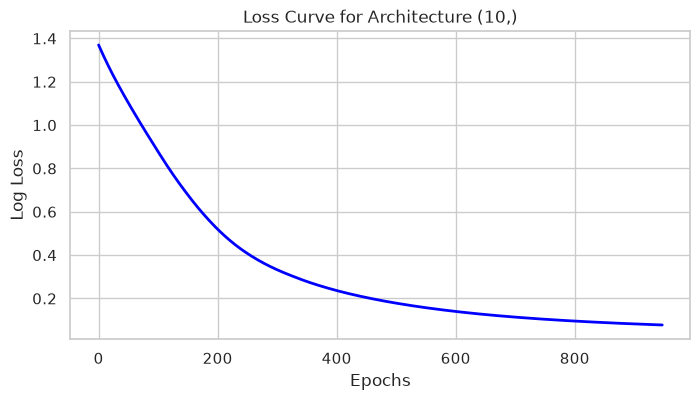

```python
# Fit the chosen pipeline on the full training set
pipe1.fit(X_train, y_train)

# Extract the MLP step from the pipeline to get the loss curve
mlp_model = pipe1.named_steps['mlpclassifier']

plt.figure(figsize=(8, 4))
plt.plot(mlp_model.loss_curve_, color='blue', linewidth=2)
plt.title(f'Loss Curve for Architecture {arch1}')
plt.xlabel('Epochs')
plt.ylabel('Log Loss')
plt.grid(True)
plt.show()
```

**Observation (Loss Curve):** The loss drops smoothly and plateaus, confirming that gradient descent successfully found a minimum without erratic spikes.

## 6. Final Evaluation on Holdout Test Set

This is the true test of our model's generalization, using data it has never seen.

```
Final Test Accuracy: 0.9667

Classification Report:
              precision    recall  f1-score   support

      setosa       1.00      1.00      1.00        10
  versicolor       1.00      0.90      0.95        10
   virginica       0.91      1.00      0.95        10

    accuracy                           0.97        30
   macro avg       0.97      0.97      0.97        30
weighted avg       0.97      0.97      0.97        30
```

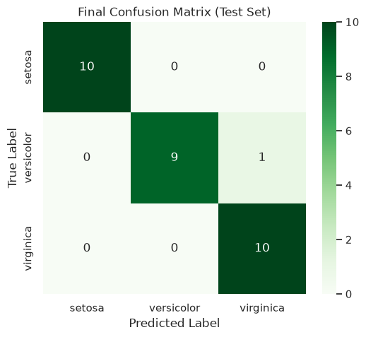

```python
# Predict on the test set
y_test_pred = pipe1.predict(X_test)
test_acc = accuracy_score(y_test, y_test_pred)

print(f"Final Test Accuracy: {test_acc:.4f}\n")
print("Classification Report:")
print(classification_report(y_test, y_test_pred, target_names=iris.target_names))

# Heatmap Confusion Matrix
cm = confusion_matrix(y_test, y_test_pred)
plt.figure(figsize=(6, 5))
sns.heatmap(cm, annot=True, fmt='d', cmap='Greens',
            xticklabels=iris.target_names, yticklabels=iris.target_names)
plt.title('Final Confusion Matrix (Test Set)')
plt.xlabel('Predicted Label')
plt.ylabel('True Label')
plt.show()
```

## 7. New Data Inference Pipeline

```python
# Because we used a Scikit-Learn Pipeline, scaling is handled AUTOMATICALLY
# during the .predict() call. We just pass raw data.
new_raw_sample = np.array([[6.0, 3.0, 4.8, 1.8]])

pred_idx = pipe1.predict(new_raw_sample)[0]
pred_prob = pipe1.predict_proba(new_raw_sample)[0]

print(f"Raw Input Features: {new_raw_sample[0]}")
print(f"Predicted Class: {iris.target_names[pred_idx].upper()}")
print(f"Confidence: {max(pred_prob)*100:.2f}%")
```

```
Raw Input Features: [6.  3.  4.8 1.8]
Predicted Class: VIRGINICA
Confidence: 69.61%
```